# Analyse statistique Forbes2000

Yassine Magroun

# Introduction

La base de données Forbes2000 regroupe des informations sur les 2000 plus grandes entreprises au monde, telles qu’évaluées par le magazine Forbes. Ce dataset constitue un outil essentiel pour les analystes, les chercheurs et les décideurs qui cherchent à saisir les dynamiques du monde des affaires à l’échelle mondiale. Il fournit une base solide pour mener des analyses approfondies sur les entreprises les plus influentes et leur impact sur l’économie globale.

```r
knitr::opts_chunk$set(root.dir ="C:/Users/Yassine/Desktop/Projet Stat")
```

## Chargement de bibliothèque nécessaires pour la lecture de Dataset

```r
library(HSAUR)
data("Forbes2000")
head(Forbes2000)
```

|  | rank | name | country | category | sales | profits | assets | marketvalue |
| --- | --- | --- | --- | --- | --- | --- | --- | --- |
| 1 | 1 | Citigroup | United States | Banking | 94.71 | 17.85 | 1264.03 | 255.30 |
| 2 | 2 | General Electric | United States | Conglomerates | 134.19 | 15.59 | 626.93 | 328.54 |
| 3 | 3 | American Intl Group | United States | Insurance | 76.66 | 6.46 | 647.66 | 194.87 |
| 4 | 4 | ExxonMobil | United States | Oil & gas operations | 222.88 | 20.96 | 166.99 | 277.02 |
| 5 | 5 | BP | United Kingdom | Oil & gas operations | 232.57 | 10.27 | 177.57 | 173.54 |
| 6 | 6 | Bank of America | United States | Banking | 49.01 | 10.81 | 736.45 | 117.55 |

### Structure du dataset

La fonction str() nous montrera la structure des données, c’est-à-dire le nombre de lignes et colonnes, les types de chaque variable (numérique, facteur, etc.), et quelques valeurs des premières observations.

```r
str(Forbes2000)
```

```
'data.frame':   2000 obs. of  8 variables:
 $ rank       : int  1 2 3 4 5 6 7 8 9 10 ...
 $ name       : chr  "Citigroup" "General Electric" "American Intl Group" "ExxonMobil" ...
 $ country    : Factor w/ 61 levels "Africa","Australia",..: 60 60 60 60 56 60 56 28 60 60 ...
 $ category   : Factor w/ 27 levels "Aerospace & defense",..: 2 6 16 19 19 2 2 8 9 20 ...
 $ sales      : num  94.7 134.2 76.7 222.9 232.6 ...
 $ profits    : num  17.85 15.59 6.46 20.96 10.27 ...
 $ assets     : num  1264 627 648 167 178 ...
 $ marketvalue: num  255 329 195 277 174 ...
```

### Description des données

Le fichier “data” contient 2000 lignes et 8 colonnes. Les lignes représentent les 2000 premières entreprises au monde, suivant les critères du classement “Forbes2000” de l’année 2004. Voici un aperçu des colonnes et de leur détails:

```r
# Obtenir le type de chaque colonne
types_colonnes <- sapply(Forbes2000, class)
print(types_colonnes)
```

```
       rank        name     country    category       sales     profits      assets marketvalue
  "integer" "character"    "factor"    "factor"   "numeric"   "numeric"   "numeric"   "numeric"
```

```r
# Charger le package knitr
library(knitr)

# Créer un data frame avec les commentaires
commentaires <- data.frame(
  Nom = c("rank", "name", "country", "category", "sales", "profits", "assets", "marketvalue"),
  Description = c(
    "Représente le rang de l'entreprise.",
    "Représente le nom de l'entreprise.",
    "Représente le pays d’origine de l’entreprise.",
    "Représente le secteur d’activité.",
    "Représente le chiffre d'affaires de l'entreprise exprimé en milliards.",
    "Représente les bénéfices de l'entreprise en milliards.",
    "Représente les actifs de l’entreprise exprimé en milliards.",
    "Représente la valeur marchande de l’entreprise exprimée en milliards."
  ),
  Type = c("Entier (Integer)", "Texte (Character)", "Texte (Character)",
           "Texte (Character)", "Décimale (Numeric)", "Décimale (Numeric)",
           "Décimale (Numeric)", "Décimale (Numeric)")
)

# Afficher le tableau
kable(commentaires, caption = "Description des colonnes du jeu de données Forbes2000")
```

Description des colonnes du jeu de données Forbes2000

[output not shown]

```r
NA
```

### on va créer un tableau interactif

```r
library(DT) # création d'un tableau interactif
datatable(Forbes2000)
```

|  | rank | name | country | category | sales | profits | assets | marketvalue |
| --- | --- | --- | --- | --- | --- | --- | --- | --- |
| 1 | 1 | Citigroup | United States | Banking | 94.71 | 17.85 | 1264.03 | 255.3 |
| 2 | 2 | General Electric | United States | Conglomerates | 134.19 | 15.59 | 626.93 | 328.54 |
| 3 | 3 | American Intl Group | United States | Insurance | 76.66 | 6.46 | 647.66 | 194.87 |
| 4 | 4 | ExxonMobil | United States | Oil &amp; gas operations | 222.88 | 20.96 | 166.99 | 277.02 |
| 5 | 5 | BP | United Kingdom | Oil &amp; gas operations | 232.57 | 10.27 | 177.57 | 173.54 |
| 6 | 6 | Bank of America | United States | Banking | 49.01 | 10.81 | 736.45 | 117.55 |
| 7 | 7 | HSBC Group | United Kingdom | Banking | 44.33 | 6.66 | 757.6 | 177.96 |
| 8 | 8 | Toyota Motor | Japan | Consumer durables | 135.82 | 7.99 | 171.71 | 115.4 |
| 9 | 9 | Fannie Mae | United States | Diversified financials | 53.13 | 6.48 | 1019.17 | 76.84 |
| 10 | 10 | Wal-Mart Stores | United States | Retailing | 256.33 | 9.05 | 104.91 | 243.74 |

[output cut: 1990 more lines]

```r
NA
```

```r
country_counts
```

[output not shown]

[output cut: 51 more lines]

```r
NA
```

```r
typeof(Forbes2000)
```

```
[1] "list"
```

## Type du dataset:

La fonction class() est utilisée pour déterminer la classe ou le type d’objet de la variable

```r
class(Forbes2000)
```

```
[1] "data.frame"
```

- La dataset “Forbes2000” est un objet de type data frame. Un data frame est une structure de données, similaire à une table dans une base de données ou une feuille de calcul dans Excel, où chaque colonne peut contenir des types de données différents (numériques, caractères, facteurs, etc.).

### Nombre de lignes et de colonnes du dataset:

Connaître le nombre de lignes et de colonnes est essentiel pour avoir une vue d’ensemble de la taille du dataset.

```r
nrow(Forbes2000)
```

```
[1] 2000
```

```r
ncol(Forbes2000)
```

```
[1] 8
```

```r
dimensions <-dim(Forbes2000)
n_lignes <- dimensions[1]
n_colonnes <- dimensions[2]
message <- paste("Notre data est composées de " , n_colonnes, "colonnes et",  n_lignes,  "lignes " )
message
```

```
[1] "Notre data est composées de  8 colonnes et 2000 lignes "
```

### Nom des colonnes et classe des objets qui les composent:

Pour avoir un aperçu sur les noms des colonnes de notre dataset, on peut utiliser la fonction names() qui retournera 8 variables représentant les noms des colonnes.

```r
names(Forbes2000) # noms des colonnes
```

```
[1] "rank"        "name"        "country"     "category"    "sales"       "profits"     "assets"      "marketvalue"
```

- On peut utiliser directement la fonction sapply(Forbes2000, class) qui nous permet non seulement d’afficher les noms des colonnes, mais aussi de connaître leurs classes.

```r
sapply(Forbes2000, class) #le type des colonnes
```

```
       rank        name     country    category       sales     profits      assets marketvalue
  "integer" "character"    "factor"    "factor"   "numeric"   "numeric"   "numeric"   "numeric"
```

- La Fonction sapply() est une fonction en R qui permet d’appliquer une fonction spécifiée dans notre cas c’est class(), à chaque élément d’un vecteur ou d’une liste. Autrement dit, elle parcourt chaque colonne et retourne son type.

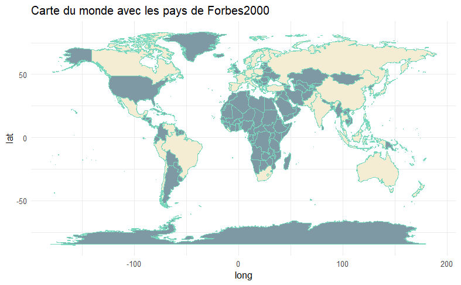

```r
library(ggplot2)
library(dplyr)
library(maps)

# Compter le nombre d'entreprises par pays
country_counts <- Forbes2000 %>%
  group_by(country) %>%
  summarise(count = n(), .groups = "drop")

# Obtenir les données de la carte
world_map <- map_data("world")

# Normaliser les noms de pays pour éviter des problèmes de correspondance
country_counts$country <- tolower(country_counts$country)
world_map$region <- tolower(world_map$region)

# Ajouter une colonne pour indiquer si le pays est dans le dataset
world_map <- world_map %>%
  left_join(country_counts, by = c("region" = "country")) %>%
  mutate(fill_color = ifelse(is.na(count), "#7E99A3", "#F4EDD3"))  # Grey for absent countries, yellow for present ones

# Créer la carte
ggplot(data = world_map) +
  geom_polygon(aes(x = long, y = lat, group = group, fill = fill_color), color = "#79D7BE") +
  theme_minimal() +
  labs(title = "Carte du monde avec les pays de Forbes2000") +
  scale_fill_identity()  # Use the fill color directly without a gradient
```

## Longueur des colonnes:

Comme toutes les colonnes d’un dataframe ont le même nombre de lignes, la longueur sera la même pour chaque colonne. Cela devrait être 2000, puisque le jeu de données contient 2000 lignes.

```r
length(Forbes2000[[1]])
```

```
[1] 2000
```

- La Fonction length() retourne la longueur d’un objet, c’est-à-dire le nombre d’éléments qu’il contient. Ici, la fonction fait référence à la première colonne du data frame “Forbes2000”.

## Nom de la première entreprise du jeu de donnés:

Pour obtenir le nom de la première entreprise dans le jeu de données, nous allons accéder à la première ligne de la colonne contenant les noms d’entreprises.

```r
# Obtenir le nom de la première entreprise
premiere_entreprise <- Forbes2000$name[1]

print(premiere_entreprise)
```

```
[1] "Citigroup"
```

## catégories d’entreprises:

A ce niveau, nous allons extraire des informations sur les différentes catégories d’entreprises présentes dans la dataset .

```r
cat <- length(unique(Forbes2000$category))
cat
```

```
[1] 27
```

```r
print(paste("Il y a", cat, "catégories d'entreprise"))
```

```
[1] "Il y a 27 catégories d'entreprise"
```

```r
category_unique <- unique(Forbes2000$category)
category_unique
```

```
 [1] Banking                          Conglomerates                    Insurance                        Oil & gas operations             Consumer durables
 [6] Diversified financials           Retailing                        Technology hardware & equipment  Food drink & tobacco             Drugs & biotechnology
[11] Telecommunications services      Software & services              Media                            Household & personal products    Semiconductors
[16] Utilities                        Transportation                   Food markets                     Chemicals                        Aerospace & defense
[21] Materials                        Capital goods                    Business services & supplies     Hotels restaurants & leisure     Construction
[26] Health care equipment & services Trading companies
27 Levels: Aerospace & defense Banking Business services & supplies Capital goods Chemicals Conglomerates Construction Consumer durables Diversified financials ... Utilities
```

```r
# Affichage de catégories divisées par /
cat("Les catégories d'entreprises sont :\n", paste(category_unique, collapse = " / "))
```

[output not shown]

- La fonction unique() extrait les valeurs uniques présentes dans la colonne category du data frame Forbes2000. Cela signifie qu’elle va éliminer les doublons et ne garder que les catégories distinctes.

## Tableau de contingence pour les catégories d’entreprises:

Un tableau de contingence est une table qui présente la répartition des données en fonction de plusieurs variables catégorielles. Il permet de visualiser la fréquence des différentes catégories de deux ou plusieurs variables. Dans le cas d’une seule variable comme dans notre cas, un tableau de contingence montre le nombre d’occurrences de chaque catégorie dans cette variable.

```r
tableau_contingence <- table(Forbes2000$category)
tableau_contingence
```

```
             Aerospace & defense                          Banking     Business services & supplies                    Capital goods                        Chemicals
                              19                              313                               70                               53                               50
                   Conglomerates                     Construction                Consumer durables           Diversified financials            Drugs & biotechnology
                              31                               79                               74                              158                               45
            Food drink & tobacco                     Food markets Health care equipment & services     Hotels restaurants & leisure    Household & personal products
                              83                               33                               65                               37                               44
                       Insurance                        Materials                            Media             Oil & gas operations                        Retailing
                             112                               97                               61                               90                               88
                  Semiconductors              Software & services  Technology hardware & equipment      Telecommunications services                Trading companies
                              26                               31                               59                               67                               25
                  Transportation                        Utilities
                              80                              110
```

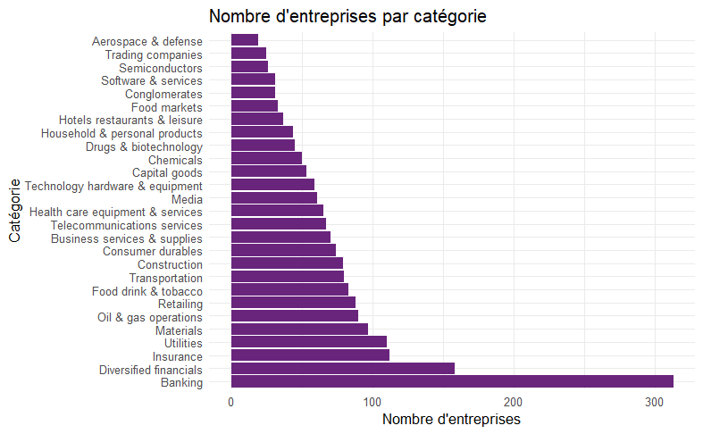

```r
library(ggplot2)
library(dplyr)

# Créer le tableau de contingence
tableau_contingence <- Forbes2000 %>%
  group_by(category) %>%
  summarise(count = n(), .groups = "drop")

# Créer le bar chart
ggplot(data = tableau_contingence, aes(x = reorder(category, -count), y = count)) +
  geom_bar(stat = "identity", fill = "#69247C") +
  theme_minimal() +
  labs(title = "Nombre d'entreprises par catégorie",
       x = "Catégorie",
       y = "Nombre d'entreprises") +
  coord_flip()  # Inverser les axes pour une meilleure lisibilité
```

-> Le graphique est un bar chart qui représente le nombre d’entreprises dans chaque catégorie du jeu de données Forbes2000. Les barres sont disposées sur l’axe des catégories, tandis que la hauteur de chaque barre indique le nombre d’entreprises correspondantes.

## Type de la colonne “Sales”:

A ce niveau nous allons voir , le type du contenu de la variable “sales” qui représente les ventes des entreprises, exprimées par des valeurs numériques.

```r
class(Forbes2000$sales)
```

```
[1] "numeric"
```

## Analyse des Statistiques Descriptives de la Variable “Sales:

Dans cette section, nous nous concentrons d’avantages sur les ventes en traitant les principales mesures statistiques (comme la médiane, la moyenne et l’étendue)

```r
#affiche le statistique descriptive de la variables sales

stats_sales <- summary(Forbes2000$sales)
stats_sales
```

```
   Min. 1st Qu.  Median    Mean 3rd Qu.    Max.
  0.010   2.018   4.365   9.697   9.547 256.330
```

```r
# Extraire la médiane, la moyenne et l'étendue
mediane <- stats_sales["Median"]
moyenne <- mean(Forbes2000$sales, na.rm = TRUE)
etendue <- range(Forbes2000$sales, na.rm = TRUE)


# Afficher les résultats

cat("Médiane des ventes :", mediane, "\n")
```

```
Médiane des ventes : 4.365
```

```r
cat("Moyenne des ventes :", moyenne, "\n")
```

```
Moyenne des ventes : 9.69701
```

```r
cat("Étendue des ventes :", etendue[1], "à", etendue[2], "\n")
```

```
Étendue des ventes : 0.01 à 256.33
```

Un résumé statistique nous donne plusieurs informations clés, nous avons utilisé la fonction summary() pour obtenir les statistiques descriptives de la colonne sales.

Min indique que la plus petite valeur de vente enregistrée dans le jeu de données est de 0,010 milliards. 1st Qu. représente le premier quartile qui signifie que 25 % des entreprises ont des ventes inférieures à 2,018 milliards. Cela donne une idée de la distribution des ventes. 3rd Qu. représente le troisième quartile indiquant que 75 % des entreprises ont des ventes inférieures à 9,547 milliards. Max représente la plus grande valeur de vente estimée à 256,330 milliards.

La médiane est la valeur centrale des données, c’est-à-dire qu’elle divise l’ensemble des ventes en deux groupes égaux En utilisant la fonction median() nous obtenons ce résultat, qui signifie que la vente médiane des entreprises est de 4,365 milliards.

La moyenne est la somme de toutes les valeurs de ventes divisées par le nombre d’entreprises. Dans notre cas en moyenne, les ventes des entreprises sont de 9,697 milliards.

L’étendue est la différence entre la valeur maximale et la valeur minimale des ventes, elle mesure l’amplitude.

256.32 représente la différence entre les ventes les plus faibles et celles les plus élevées

## Représentation graphique du jeu de données

Avant de passer aux représentations graphiques, nous allons obtenir les statistiques descriptives de notre ensemble de données, pour les visualisations par la suite. C’est similaire à ce que nous avons fait avec la colonne des ventes, mais maintenant nous allons le faire pour toutes les colonnes.

```r
summary(Forbes2000)
```

```
      rank            name                     country                      category        sales            profits             assets          marketvalue
 Min.   :   1.0   Length:2000        United States :751   Banking               : 313   Min.   :  0.010   Min.   :-25.8300   Min.   :   0.270   Min.   :  0.02
 1st Qu.: 500.8   Class :character   Japan         :316   Diversified financials: 158   1st Qu.:  2.018   1st Qu.:  0.0800   1st Qu.:   4.025   1st Qu.:  2.72
 Median :1000.5   Mode  :character   United Kingdom:137   Insurance             : 112   Median :  4.365   Median :  0.2000   Median :   9.345   Median :  5.15
 Mean   :1000.5                      Germany       : 65   Utilities             : 110   Mean   :  9.697   Mean   :  0.3811   Mean   :  34.042   Mean   : 11.88
 3rd Qu.:1500.2                      France        : 63   Materials             :  97   3rd Qu.:  9.547   3rd Qu.:  0.4400   3rd Qu.:  22.793   3rd Qu.: 10.60
 Max.   :2000.0                      Canada        : 56   Oil & gas operations  :  90   Max.   :256.330   Max.   : 20.9600   Max.   :1264.030   Max.   :328.54
                                     (Other)       :612   (Other)               :1120                     NA's   :5
```

Passons maintenant à la visualization de ces données, voici quelques fonctions utilises dans ce but:

[figure not shown]

```r
# Disposition de 2 graphiques l'un sous l'autre
layout(matrix(1:2, nrow = 2))

# Premier histogramme : Valeur marchande des entreprises
hist(Forbes2000$marketvalue,
     main = "Histogramme de la valeur marchande",
     xlab = "Valeur marchande (en milliards)",
     col = "#66785F")

# Deuxième histogramme : Logarithme de la valeur marchande
hist(log(Forbes2000$marketvalue),
     main = "Histogramme (log) de la valeur marchande",
     xlab = "Log de la valeur marchande",
     col = "#A1EEBD")
```

- layout(matrix(1:2, nrow=2)) : Crée une matrice (2,1) pour disposer deux graphiques, un sur chaque ligne.
- hist(Forbes2000$marketvalue) : Affiche l’histogramme de la distribution des valeurs de la colonne “market value”.
- hist(log(Forbes2000$marketvalue)) : Trace l’histogramme des valeurs logarithmiques de market value.

## Visualisation de la corrélation entre Log(sales) et Log(marketvalue):

Pour tracer un graphique montrant la relation entre la valeur du marché et les ventes, nous avons utilisé la fonction plot() pour créer un graphique à dispersion appelé “scatter plot”. Les valeurs logarithmiques des ventes sont représentées au niveau de l’axe des x et celui de la valeur de marché sur l’axe y.

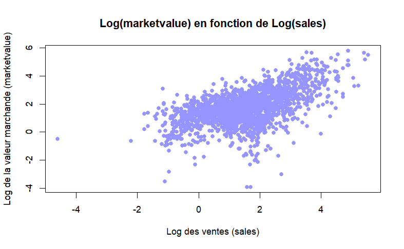

```r
# Créer le diagramme de dispersion avec des échelles logarithmiques
plot(log(Forbes2000$sales), log(Forbes2000$marketvalue),
     main = "Log(marketvalue) en fonction de Log(sales)",
     xlab = "Log des ventes (sales)",
     ylab = "Log de la valeur marchande (marketvalue)",
     pch = 19,    # Style des points
     col = "#9694FF")  # Couleur des points
```

## Distribution Logarithmique des Valeurs de Marché pour l’Allemagne, l’Inde, la Turquie et le Royaume-Uni:

Pour faire la comparaison de la distribution logarithmique des valeurs de marché, on a commencé par créer un nouveau data frame “forbes_subset” qui contient uniquement les lignes pour les pays sélectionnés : Allemagne, Inde, Turquie et Royaume-Uni.

Cela permet de se concentrer sur un échantillon spécifique de données sans interférence d’autres pays.

```r
# Filtrer les données pour les pays sélectionnés
pays_selectionnes <- subset(Forbes2000 , country %in% c("Germany", "India", "Turkey", "United Kingdom"))
```

Dans cette démarche la fonction subset() est utilisée pour créer un sous-ensemble du data frame “Forbes2000” . “%in%” est un opérateur qui teste si les valeurs de la colonne “country” figurent dans ce vecteur c(“Germany”, “India”, “Turkey”, “United Kingdom”)

```r
Forbes_selec <-pays_selectionnes
Forbes_selec$country <- droplevels(Forbes_selec$country )
```

Après avoir créé un sous-ensemble, il peut y avoir des niveaux de facteur dans “country” qui ne sont plus utilisés. droplevels() supprime ces niveaux inutilisés, ce qui rend les analyses et les visualisations plus propres.

```r
# Transformation logarithmique de marketvalue
Forbes_selec$log_marketvalue <- log(Forbes_selec$marketvalue)
```

Cette ligne applique a la suite la transformation logarithmique à la variable “marketvalue” et stocke le résultat dans une nouvelle colonne.

#### Maintenant, nous pouvons tracer notre boxplot ou le diagramme en boîte, un outil graphique utilisé pour représenter la distribution d’un ensemble de données. Il permet de visualiser la médiane, les quartiles, l’intervalle interquartile et les valeurs aberrantes.

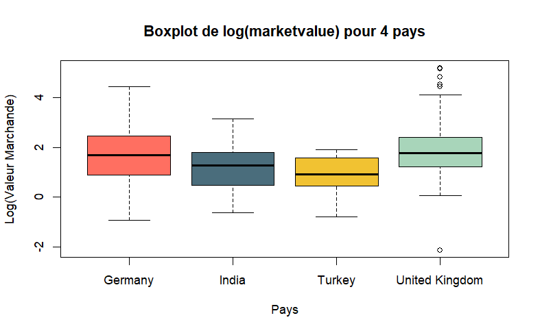

```r
# Tracer les boxplots de log(marketvalue) pour chaque pays
boxplot(log_marketvalue ~ country, data = Forbes_selec,
        main = "Boxplot de log(marketvalue) pour 4 pays",
        xlab = "Pays",
        ylab = "Log(Valeur Marchande)",
        col = c("#FF6F61", "#4A6D7C", "#F1C232", "#A8D5BA"))
```

On a utilisé la fonction boxplot() pour créer le diagramme en boîte, les paramètres main,xlab et ylab ajoutent des titres et des étiquettes pour clarifier le graphique, tandis que col définit les couleurs des boxplots.

## Modification des valeurs aberantes

on peux utiliser la fonction boxplot.stats() pour obtenir les valeurs aberrantes du Royaume-Uni (United Kingdom).

```r
# Obtenir les valeurs aberrantes pour United Kingdom
uk_outliers <- boxplot.stats(Forbes_selec$log_marketvalue[Forbes_selec$country == "United Kingdom"])$out

# Afficher les valeurs aberrantes
uk_outliers
```

```
[1]  5.156408  5.181559  4.502140  4.826632  4.419202  5.162555 -2.120264
```

nous avons décides de supprimer les valeurs aberrantes, tu peux filtrer le jeu de données pour exclure les valeurs identifiées.

```r
# Supprimer les valeurs aberrantes pour United Kingdom
Forbes_selec_clean <- Forbes_selec[!(Forbes_selec$log_marketvalue %in% uk_outliers &
                                    Forbes_selec$country == "United Kingdom"), ]
```

- boxplot.stats() : Cette fonction extrait les statistiques du boxplot, y compris les valeurs aberrantes. On l’utilise ici pour identifier les outliers du Royaume-Uni.

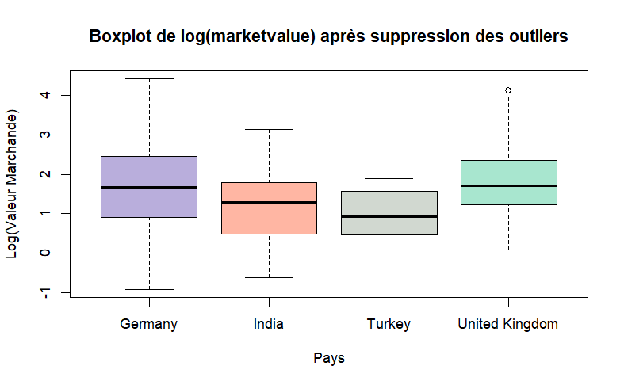

```r
# Tracer les boxplots après avoir supprimé les outliers du Royaume-Uni
boxplot(log_marketvalue ~ country, data = Forbes_selec_clean,
        main = "Boxplot de log(marketvalue) après suppression des outliers",
        xlab = "Pays",
        ylab = "Log(Valeur Marchande)",
        col = c("#B9AEDC", "#FFB6A3", "#D1D8D0", "#A8E6CF"))
```

### verifier s’il reste encore des valeurs aberantes

```r
# Vérifier s'il reste des outliers après suppression
uk_outliers_remaining <- boxplot.stats(Forbes_selec_clean$log_marketvalue[Forbes_selec_clean$country == "United Kingdom"])$out

# Afficher les valeurs aberrantes restantes
uk_outliers_remaining
```

```
[1] 4.116269
```

- il reste encore une valeurs alors , on va le supprime aussi

```r
# Supprimer les nouvelles valeurs aberrantes détectées pour United Kingdom
Forbes_selec_clean <- Forbes_selec_clean[!(Forbes_selec_clean$log_marketvalue %in% uk_outliers_remaining &
                                          Forbes_selec_clean$country == "United Kingdom"), ]
```

## tracage de boxplot sans valeurs aberrantes:

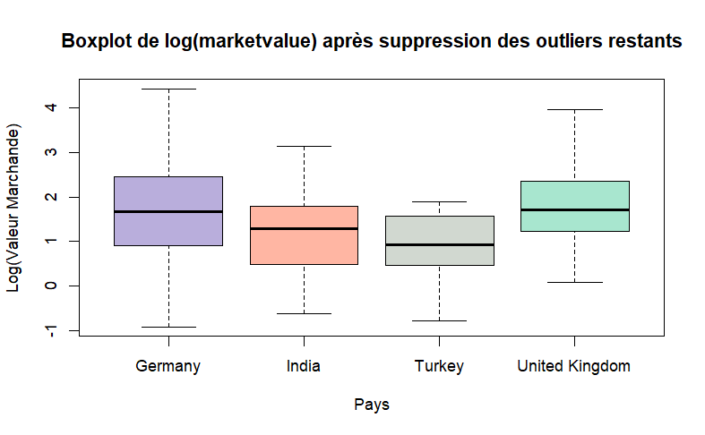

```r
# Tracer les boxplots après suppression des outliers restants
boxplot(log_marketvalue ~ country, data = Forbes_selec_clean,
        main = "Boxplot de log(marketvalue) après suppression des outliers restants",
        xlab = "Pays",
        ylab = "Log(Valeur Marchande)",
        col = c("#B9AEDC", "#FFB6A3", "#D1D8D0", "#A8E6CF"))
```

## Analyse des Corrélations

une analyse de corrélation entre les différentes variables numériques comme sales, profits, assets, et marketvalue. Une matrice de corrélation visualisée par un heatmap pourrait révéler des liens intéressants entre ces mesures financières

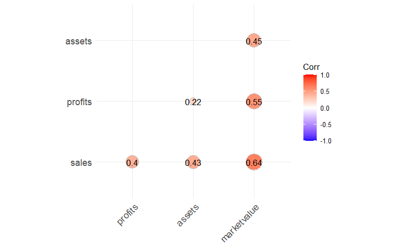

```r
library(ggcorrplot)
num_data <- Forbes2000[, c("sales", "profits", "assets", "marketvalue")]
correlation_matrix <- cor(num_data, use = "complete.obs")
ggcorrplot(correlation_matrix, method = "circle", type = "lower", lab = TRUE)
```

- Les sales et la market value sont les deux indicateurs les plus fortement corrélés avec les autres variables, notamment avec les profits et les assets. En revanche, la relation entre les profits et les assets est beaucoup plus faible, ce qui suggère que des facteurs autres que la taille des assets peuvent jouer un rôle majeur dans la rentabilité d’une entreprise.

## Filtrage des entreprises par continent

Dans cette section, nous allons effectuer un filtre pour analyser les entreprises en fonction de leur continent d’origine. Nous explorerons successivement chaque continent et extrairons les données pertinentes.

```r
install.packages("countrycode")
```

```
Error in install.packages : Updating loaded packages
```

```r
library(countrycode)
# Ajouter une colonne 'continent' en fonction de la colonne 'country'
Forbes2000$continent <- countrycode(Forbes2000$country,
                                    origin = "country.name",
                                    destination = "continent")
# Vérifier les premières lignes avec la nouvelle colonne 'continent'
head(Forbes2000)
```

|  | rank | name | country | category | sales | profits | assets | marketvalue | continent |
| --- | --- | --- | --- | --- | --- | --- | --- | --- | --- |
| 1 | 1 | Citigroup | United States | Banking | 94.71 | 17.85 | 1264.03 | 255.30 | Americas |
| 2 | 2 | General Electric | United States | Conglomerates | 134.19 | 15.59 | 626.93 | 328.54 | Americas |
| 3 | 3 | American Intl Group | United States | Insurance | 76.66 | 6.46 | 647.66 | 194.87 | Americas |
| 4 | 4 | ExxonMobil | United States | Oil & gas operations | 222.88 | 20.96 | 166.99 | 277.02 | Americas |
| 5 | 5 | BP | United Kingdom | Oil & gas operations | 232.57 | 10.27 | 177.57 | 173.54 | Europe |
| 6 | 6 | Bank of America | United States | Banking | 49.01 | 10.81 | 736.45 | 117.55 | Americas |

### Continent Américain

```r
# Filtrer les entreprises basées en Amérique
america_companies <- Forbes2000 %>%
  filter(continent == "Americas")

# Afficher les premières lignes du dataset filtré
head(america_companies)
```

|  | rank | name | country | category | sales | profits | assets | marketvalue | continent |
| --- | --- | --- | --- | --- | --- | --- | --- | --- | --- |
| 1 | 1 | Citigroup | United States | Banking | 94.71 | 17.85 | 1264.03 | 255.30 | Americas |
| 2 | 2 | General Electric | United States | Conglomerates | 134.19 | 15.59 | 626.93 | 328.54 | Americas |
| 3 | 3 | American Intl Group | United States | Insurance | 76.66 | 6.46 | 647.66 | 194.87 | Americas |
| 4 | 4 | ExxonMobil | United States | Oil & gas operations | 222.88 | 20.96 | 166.99 | 277.02 | Americas |
| 6 | 6 | Bank of America | United States | Banking | 49.01 | 10.81 | 736.45 | 117.55 | Americas |
| 9 | 9 | Fannie Mae | United States | Diversified financials | 53.13 | 6.48 | 1019.17 | 76.84 | Americas |

```r
NA
```

### Continent Européen

```r
# Filtrer les entreprises basées en Europe
europe_companies <- Forbes2000 %>%
  filter(continent == "Europe")

# Afficher les premières lignes du dataset filtré
head(europe_companies)
```

|  | rank | name | country | category | sales | profits | assets | marketvalue | continent |
| --- | --- | --- | --- | --- | --- | --- | --- | --- | --- |
| 5 | 5 | BP | United Kingdom | Oil & gas operations | 232.57 | 10.27 | 177.57 | 173.54 | Europe |
| 7 | 7 | HSBC Group | United Kingdom | Banking | 44.33 | 6.66 | 757.60 | 177.96 | Europe |
| 11 | 11 | UBS | Switzerland | Diversified financials | 48.95 | 5.15 | 853.23 | 85.07 | Europe |
| 12 | 12 | ING Group | Netherlands | Diversified financials | 94.72 | 4.73 | 752.49 | 54.59 | Europe |
| 17 | 17 | Total | France | Oil & gas operations | 131.64 | 8.84 | 87.84 | 116.64 | Europe |
| 18 | 18 | BNP Paribas | France | Banking | 47.74 | 4.73 | 745.09 | 59.29 | Europe |

```r
NA
```

### Continent Asiatique

```r
install.packages("dplyr")
library(dplyr)
# Filtrer les entreprises basées en Asie
asia_companies <- Forbes2000 %>%
  filter(continent == "Asia")

# Afficher les premières lignes du dataset filtré
head(asia_companies)
```

|  | rank | name | country | category | sales | profits | assets | marketvalue | continent |
| --- | --- | --- | --- | --- | --- | --- | --- | --- | --- |
| 8 | 8 | Toyota Motor | Japan | Consumer durables | 135.82 | 7.99 | 171.71 | 115.40 | Asia |
| 30 | 30 | Nippon Tel & Tel | Japan | Telecommunications services | 92.41 | 2.17 | 150.87 | 73.00 | Asia |
| 45 | 45 | Samsung Electronics | South Korea | Semiconductors | 50.22 | 5.95 | 54.58 | 72.72 | Asia |
| 49 | 49 | Honda Motor | Japan | Consumer durables | 67.44 | 3.61 | 63.09 | 40.61 | Asia |
| 51 | 51 | Nissan Motor | Japan | Consumer durables | 57.77 | 4.19 | 60.56 | 41.71 | Asia |
| 55 | 55 | PetroChina | China | Oil & gas operations | 29.53 | 5.67 | 58.36 | 90.49 | Asia |

```r
NA
NA
```

### Continent Africain

```r
# Filtrer les entreprises basées en Africa
africa_companies <- Forbes2000 %>%
  filter(continent == "Africa")

# Afficher les premières lignes du dataset filtré
head(africa_companies)
```

|  | rank | name | country | category | sales | profits | assets | marketvalue | continent |
| --- | --- | --- | --- | --- | --- | --- | --- | --- | --- |
| 359 | 359 | Standard Bank Group | South Africa | Banking | 5.14 | 0.58 | 45.45 | 8.10 | Africa |
| 377 | 377 | Firstrand | South Africa | Banking | 4.69 | 0.61 | 52.81 | 7.62 | Africa |
| 417 | 417 | Sasol | South Africa | Oil & gas operations | 8.64 | 1.05 | 9.36 | 9.33 | Africa |
| 522 | 522 | ABSA Group | South Africa | Diversified financials | 4.99 | 0.43 | 34.06 | 4.46 | Africa |
| 675 | 675 | Royal Caribbean | Liberia | Hotels restaurants & leisure | 3.78 | 0.28 | 11.32 | 8.09 | Africa |
| 793 | 793 | Telkom | South Africa | Telecommunications services | 4.76 | 0.21 | 6.64 | 6.10 | Africa |

```r
NA
```